# BAX 452_HW#2_Yuxin Yi copy 2

### Assignment 1: Linear Regression and FDR

##### Author: Yuxin (Raychel) Yi

##### Team 6: Yuxin (Raychel) Yi, Tien (Candice) Her, Manickashree Thayumana Sundaram

#### Question 1

1. **Data Exploration and Visualization** (15 pts):
- Explore the Breast Cancer Dataset.
- Provide visualizations such as histograms, scatter plots, or box plots to understand the distribution of different features.
- Include any other plots you find interesting and provide brief interpretations.

```python
# Importing necessary libraries
import pandas as pd
import matplotlib.pyplot as plt
import seaborn as sns
import statsmodels.formula.api as smf
import statsmodels.api as sm
import itertools
from itertools import combinations
import numpy as np
from sklearn.model_selection import train_test_split, KFold, cross_val_score
from sklearn.metrics import confusion_matrix, classification_report, precision_score, mean_squared_error
from sklearn.base import BaseEstimator, RegressorMixin
from statsmodels.regression.linear_model import OLS

# Load the dataset
df = pd.read_csv('/Users/guanliyuan/Desktop/BAX 452 ML/BAX 452_HW#2/Cancer.csv')
df = df.loc[:, ~df.columns.str.contains('^Unnamed')]

# View the data
df.head()
```

|  | id | diagnosis | radius_mean | texture_mean | perimeter_mean | area_mean | smoothness_mean | compactness_mean | concavity_mean | concave points_mean | ... | radius_worst | texture_worst | perimeter_worst | area_worst | smoothness_worst | compactness_worst | concavity_worst | concave points_worst | symmetry_worst | fractal_dimension_worst |
| --- | --- | --- | --- | --- | --- | --- | --- | --- | --- | --- | --- | --- | --- | --- | --- | --- | --- | --- | --- | --- | --- |
| 0 | 842302 | M | 17.99 | 10.38 | 122.80 | 1001.0 | 0.11840 | 0.27760 | 0.3001 | 0.14710 | ... | 25.38 | 17.33 | 184.60 | 2019.0 | 0.1622 | 0.6656 | 0.7119 | 0.2654 | 0.4601 | 0.11890 |
| 1 | 842517 | M | 20.57 | 17.77 | 132.90 | 1326.0 | 0.08474 | 0.07864 | 0.0869 | 0.07017 | ... | 24.99 | 23.41 | 158.80 | 1956.0 | 0.1238 | 0.1866 | 0.2416 | 0.1860 | 0.2750 | 0.08902 |
| 2 | 84300903 | M | 19.69 | 21.25 | 130.00 | 1203.0 | 0.10960 | 0.15990 | 0.1974 | 0.12790 | ... | 23.57 | 25.53 | 152.50 | 1709.0 | 0.1444 | 0.4245 | 0.4504 | 0.2430 | 0.3613 | 0.08758 |
| 3 | 84348301 | M | 11.42 | 20.38 | 77.58 | 386.1 | 0.14250 | 0.28390 | 0.2414 | 0.10520 | ... | 14.91 | 26.50 | 98.87 | 567.7 | 0.2098 | 0.8663 | 0.6869 | 0.2575 | 0.6638 | 0.17300 |
| 4 | 84358402 | M | 20.29 | 14.34 | 135.10 | 1297.0 | 0.10030 | 0.13280 | 0.1980 | 0.10430 | ... | 22.54 | 16.67 | 152.20 | 1575.0 | 0.1374 | 0.2050 | 0.4000 | 0.1625 | 0.2364 | 0.07678 |

5 rows × 32 columns

#### Plot 1: Histograms of features

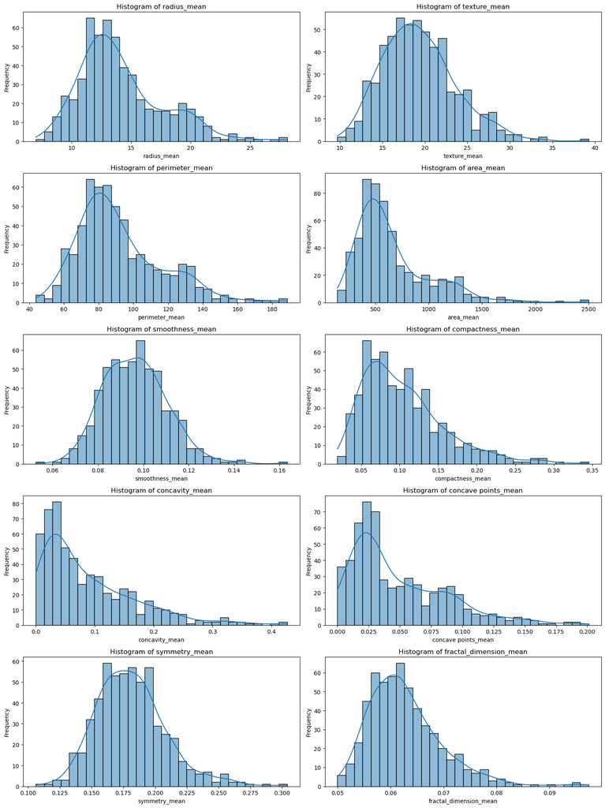

```python
# Select the features
features = ['radius_mean', 'texture_mean', 'perimeter_mean', 'area_mean', 'smoothness_mean',
                     'compactness_mean', 'concavity_mean', 'concave points_mean', 'symmetry_mean',
                     'fractal_dimension_mean']

# Creating histograms
plt.figure(figsize=(15, 20))
for i, feature in enumerate(features):
    plt.subplot(5, 2, i+1)
    sns.histplot(df[feature], kde=True, bins=30)
    plt.title(f'Histogram of {feature}')
    plt.xlabel(feature)
    plt.ylabel('Frequency')

plt.tight_layout()
plt.show()
```

#### Plot 2: Box plots of features

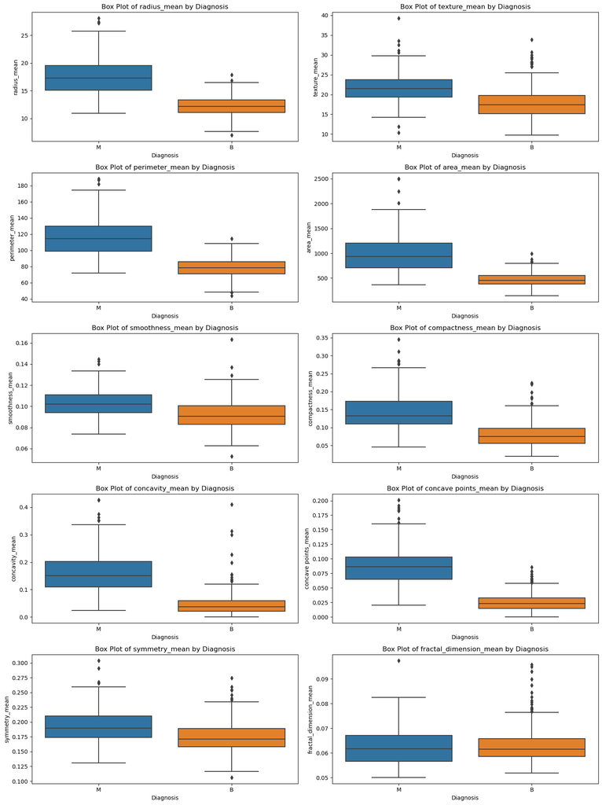

```python
# Creating box plots for features, segmented by diagnosis
plt.figure(figsize=(15, 20))

for i, feature in enumerate(features):
    plt.subplot(5, 2, i+1)
    sns.boxplot(x='diagnosis', y=feature, data=df)
    plt.title(f'Box Plot of {feature} by Diagnosis')
    plt.xlabel('Diagnosis')
    plt.ylabel(feature)

plt.tight_layout()
plt.show()
```

Interpretation: These box plots illustrate the differences in the distributions of these features between malignant and benign tumors. Generally, malignant tumors tend to have higher values in most of these features compared to benign tumors.

#### Plot 3: Heatmap of features

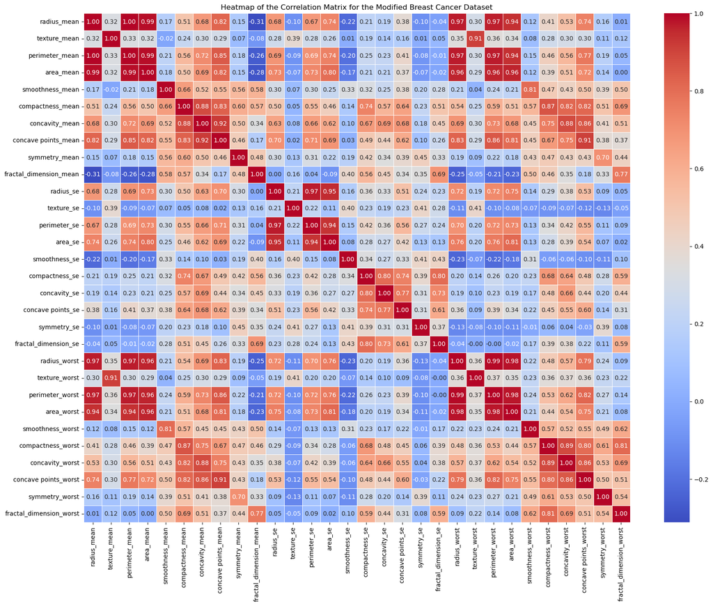

```python
df = df.drop(columns=['id'])

# Calculating the correlation matrix
correlation_matrix_modified = df.corr()

# Plotting the heatmap
plt.figure(figsize=(20, 15))
sns.heatmap(correlation_matrix_modified, annot=True, fmt='.2f', cmap='coolwarm', linewidths=.5)
plt.title('Heatmap of the Correlation Matrix for the Modified Breast Cancer Dataset')
plt.show()
```

#### Question 2

1. **Logistic Regression Model Development** (20 pts):
- Develop a logistic regression model to predict whether cancer is malignant or benign.
- Preprocess the data as necessary (handling missing values, encoding categorical variables, etc.).
- Explain the steps you took in preparing the data and developing the model.
- You might need to encode the values for your prediction.

From the correlation matrix above, we can verify the presence of multicollinearity between some variables. The multicollienartiy occurs between the "mean" columns and the "worst" column. So we drop all "worst" columns from the dataset.

Another place where multicollinearity is apparent is among radius_mean, perimeter_mean, and area_mean. This is probably because the three columns essentially contain the same information, which is the physical size of the observation (the cell). Therefore we pick one of the three columns for further analysis.

```python
# encoding
from sklearn.preprocessing import LabelEncoder
label_encode = LabelEncoder()
df.loc[:, "diagnosis"] = label_encode.fit_transform(df.loc[:, "diagnosis"])
```

```python
from sklearn.model_selection import train_test_split
import statsmodels.api as sm

# Drop all "worst" columns because of multicollinearity
cols1 = ['radius_worst',
        'texture_worst',
        'perimeter_worst',
        'area_worst',
        'smoothness_worst',
        'compactness_worst',
        'concavity_worst',
        'concave points_worst',
        'symmetry_worst',
        'fractal_dimension_worst']

# Drop all columns related to the "perimeter" and "area" attributes
cols2 = ['perimeter_mean',
        'perimeter_se',
        'area_mean',
        'area_se']

cols_to_drop = cols1 + cols2
df = df.drop(cols_to_drop, axis=1)
```

```python
x = df.drop(["diagnosis"], axis=1)
y = df['diagnosis']

X_train, X_test, y_train, y_test = train_test_split(x, y, test_size=0.2,random_state=42)

model1 = LogisticRegression(solver='lbfgs', max_iter=1000000)
model1.fit(X_train, y_train)
```

```
LogisticRegression(max_iter=1000000)
```

#### Question 3

1. **Model Evaluation** (20 pts):
- Evaluate your logistic regression model using appropriate metrics (e.g., accuracy, R^2, RMSE (all out-of-sample)).
- Split the dataset into training and testing sets to perform this evaluation.
- Interpret these metrics to assess the performance of your model. Is it good? Why?

```python
from sklearn.metrics import accuracy_score, mean_squared_error, r2_score
from sklearn.metrics import classification_report, roc_auc_score
from math import sqrt

# Predict on the test data
y_pred = model1.predict(X_test)
y_pred_prob = model1.predict_proba(X_test)[:, 1]

# Calculate the Accuracy
accuracy = accuracy_score(y_test, y_pred) * 100
print(f'Accuracy: {accuracy:.2f}%')

# Calculate the RMSE
rmse = sqrt(mean_squared_error(y_test, y_pred_prob))
print(f'RMSE: {rmse:.4f}')

# Calculate the R-squared
r_squared = r2_score(y_test, y_pred_prob)
print(f'R-squared: {r_squared:.4f}')

# Calculate ROC-AUC
roc_auc = roc_auc_score(y_test, y_pred_prob)
print(f'ROC-AUC: {roc_auc:.4f}')

# Classification metrics
print(classification_report(y_test, y_pred))
```

```
Accuracy: 92.11%
RMSE: 0.2275
R-squared: 0.7797
ROC-AUC: 0.9856
              precision    recall  f1-score   support

           0       0.92      0.96      0.94        71
           1       0.93      0.86      0.89        43

    accuracy                           0.92       114
   macro avg       0.92      0.91      0.91       114
weighted avg       0.92      0.92      0.92       114
```

**Interpretation:**

1. *Accuracy (92.11%):* The accuracy rate indicates that the model correctly predicted the outcome for approximately 92.11% of the test data. This suggests that the model is comparatively highly effective in classifying the instances correctly.
2. *RMSE (0.2275):* The RMSE of 0.2275 suggests that the model’s predictions are close to the actual values on average, since the lower RMSE value would indicate better fit. However, as RMSE does not have an intuitive scale like accuracy (0-100%), it's a bit harder to interpret in isolation and is better used comparatively (e.g., against other models).
3. *R-squared (0.7797):* An R-squared value of 0.7797 means that approximately 77.97% of the variance in the dependent variable is explained by the model.
4. *AUC (0.9856):*An AUC score of 0.9856 means that the model has a 98.56% chance of correctly distinguishing between the positive class and the negative class, suggests that the model has excellent measure of separability.

Overall, based on these metrics, this logistic regression model seems to perform very well. The high accuracy and AUC indicate effective classification, and the RMSE and R-squared values suggest a good fit to the data.

#### Question 4

1. **Testing Interactions Between Features** (30 pts):
- Explore and test the interactions between different features in the dataset. Pay particular attention to interactions involving both categorical/dummy and continuous variables.
- For this excercise, use a linear regression rather than a logistic regression model.
- Discuss issues that occur when using a linear regression model to predict binary outcomes.
- Create and analyze interaction terms involving categorical/dummy variables (such as 'diagnosis' converted into a dummy variable) and continuous variables (like 'radius_mean' or 'texture_mean').
- Fit a regression model that includes interaction terms, for example, between 'diagnosis' and 'radius_mean', and between 'diagnosis' and 'texture_mean'.
- Discuss the influence of these interactions on the model. Describe how to interpret these interactions and their implications for understanding the data.

```python
import pandas as pd
import statsmodels.api as sm
from itertools import combinations
from sklearn.model_selection import train_test_split

# Create interaction terms
df2 = df.copy()
df2["interaction_radius"] = df2["diagnosis"]*df2["radius_mean"]
df2["interaction_texture"] = df2["diagnosis"]*df2["texture_mean"]

x = df2.drop(["diagnosis"], axis=1)
y = df2["diagnosis"]
X_train, X_test, y_train, y_test = train_test_split(x, y, test_size=0.2, random_state=42)

# Add a constant to the model
X_train_const = sm.add_constant(X_train)

# Fit the linear regression model
model2 = sm.OLS(y_train, X_train_const).fit()

# Print the summary
print(model2.summary())
```

```
                            OLS Regression Results
==============================================================================
Dep. Variable:              diagnosis   R-squared:                       0.987
Model:                            OLS   Adj. R-squared:                  0.987
Method:                 Least Squares   F-statistic:                     1877.
Date:                Thu, 25 Jan 2024   Prob (F-statistic):               0.00
Time:                        23:38:56   Log-Likelihood:                 677.88
No. Observations:                 455   AIC:                            -1318.
Df Residuals:                     436   BIC:                            -1239.
Df Model:                          18
Covariance Type:            nonrobust
==========================================================================================
                             coef    std err          t      P>|t|      [0.025      0.975]
------------------------------------------------------------------------------------------
const                      0.7269      0.089      8.213      0.000       0.553       0.901
radius_mean               -0.0314      0.003    -11.234      0.000      -0.037      -0.026
texture_mean              -0.0063      0.001     -6.757      0.000      -0.008      -0.004
smoothness_mean            0.8153      0.365      2.234      0.026       0.098       1.533
compactness_mean           1.0368      0.235      4.407      0.000       0.574       1.499
concavity_mean            -0.0191      0.202     -0.095      0.925      -0.417       0.378
concave points_mean       -0.7284      0.425     -1.714      0.087      -1.564       0.107
symmetry_mean             -0.0415      0.140     -0.297      0.766      -0.316       0.233
fractal_dimension_mean    -5.1852      1.115     -4.649      0.000      -7.378      -2.993
radius_se                 -0.0597      0.015     -3.855      0.000      -0.090      -0.029
texture_se                 0.0078      0.007      1.183      0.238      -0.005       0.021
smoothness_se             -6.7176      1.184     -5.676      0.000      -9.044      -4.391
compactness_se            -0.8462      0.440     -1.925      0.055      -1.710       0.018
concavity_se              -0.2604      0.296     -0.881      0.379      -0.841       0.321
concave points_se          2.7957      1.011      2.764      0.006       0.808       4.783
symmetry_se                0.1231      0.439      0.280      0.779      -0.740       0.987
fractal_dimension_se       4.4340      2.268      1.955      0.051      -0.023       8.891
interaction_radius         0.0459      0.002     25.677      0.000       0.042       0.049
interaction_texture        0.0168      0.001     14.118      0.000       0.014       0.019
==============================================================================
Omnibus:                        3.168   Durbin-Watson:                   2.073
Prob(Omnibus):                  0.205   Jarque-Bera (JB):                3.563
Skew:                          -0.031   Prob(JB):                        0.168
Kurtosis:                       3.429   Cond. No.                     2.53e+04
==============================================================================

Notes:
[1] Standard Errors assume that the covariance matrix of the errors is correctly specified.
[2] The condition number is large, 2.53e+04. This might indicate that there are
strong multicollinearity or other numerical problems.
```

**Issues issues that occur when using a linear regression model to predict binary outcomes**: When linear regression is applied to binary outcomes, there are inherent issues due to the model's assumptions that are not suitable for binary data. Linear regression assumes that the dependent variable is continuous, but binary outcomes are categorical with only two values, 0 and 1. This mismatch can result in predicted values that are less than 0 or greater than 1, which are not meaningful in a binary context. Moreover, the assumption of homoscedasticity, where the variance of errors is constant across all levels of independent variables, is likely violated in binary outcome models. This can lead to incorrect standard errors and confidence intervals, thus compromising the statistical inferences that can be drawn from the model.

**Influence of these interactions on the model**:The significance of the interaction terms between "diagnosis" and "radius_mean" and "texture_mean" in the linear regression model emphasizes that the impact of these continuous variables on the likelihood of a specific diagnosis depends on the diagnostic status itself. Significant positive interactions indicate that the relationship between tumor characteristics (such as size and texture) and diagnosis is stronger or more pronounced for patients with a certain diagnosis. This insight reveals how medical assessments can benefit from taking these interactions into account, enabling more personalized approaches to diagnosis and treatment.

#### Question 5

1. **Feature Selection and Cross-Validation: Full vs. Reduced Model** (15 pts):
- Create a reduced model using only a subset of significant predictors. You can use methods like FDR Cutoff, forward selection, backward elimination, or any other appropriate feature selection technique.
- Compare the performance of the full model (using all predictors) with the reduced model (using significant predictors) using 10-fold cross-validation.
- Evaluate the out-of-sample performance for both models across folds and discuss which model performs better and why.

```python
import pandas as pd
from sklearn.model_selection import train_test_split, cross_val_score, StratifiedKFold
from sklearn.linear_model import LogisticRegression
from sklearn.preprocessing import StandardScaler
from sklearn.pipeline import make_pipeline
from sklearn.feature_selection import RFE

X_full = df.drop('diagnosis', axis=1)
y = df['diagnosis']

# Create the full logistic regression pipeline
pipeline_full = make_pipeline(StandardScaler(), LogisticRegression(solver='lbfgs', max_iter=10000000))

# Perform 10-fold cross-validation for the full model
cv_full = StratifiedKFold(n_splits=10, shuffle=True, random_state=42)
scores_full = cross_val_score(pipeline_full, X_full, y, cv=cv_full, scoring='accuracy')

# Select features with Recursive Feature Elimination
logreg = LogisticRegression(solver='lbfgs', max_iter=10000000)
rfe = RFE(logreg, n_features_to_select=5)  # Adjust n_features_to_select
X_reduced = rfe.fit_transform(X_full, y)

# Create the reduced logistic regression pipeline
pipeline_reduced = make_pipeline(StandardScaler(), LogisticRegression(solver='lbfgs', max_iter=10000000))

# Perform 10-fold cross-validation for the reduced model
scores_reduced = cross_val_score(pipeline_reduced, X_reduced, y, cv=cv_full, scoring='accuracy')

# Output the cross-validation results
print("Full Model CV Accuracy: %0.2f (+/- %0.2f)" % (scores_full.mean(), scores_full.std() * 2))
print("Reduced Model CV Accuracy: %0.2f (+/- %0.2f)" % (scores_reduced.mean(), scores_reduced.std() * 2))
```

```
Full Model CV Accuracy: 0.96 (+/- 0.04)
Reduced Model CV Accuracy: 0.91 (+/- 0.08)
```

The full model, which incorporates all predictors, yields a higher cross-validation accuracy of 0.96 with a relatively small variability (± 0.04). In contrast, the reduced model—comprising only significant predictors—has a lower accuracy of 0.91 and greater variability (± 0.08). This suggests that, despite the risk of overfitting, the full model is more accurate in its predictions. The higher accuracy of the full model could be attributed to its utilization of all available features in the dataset, so it could capture more intricate relationships and patterns that might be present in the data.